# Cover Sheet

By including this statement, we, all the students listed in the table below, declare that:

- We hold a copy of this assignment if the original is lost or damaged.
- We hereby certify that no part of this assignment has been copied from any other student’s work or from any other source except where due acknowledgement is made in the assignment.
- No part of the assignment has been written for us by any other person except where collaboration has been authorised by the unit coordinator.
- We are aware that this work may be reproduced and submitted to plagiarism detection software programs for the purpose of detecting possible plagiarism; this software may retain a copy on its database for future plagiarism checking.
- We hereby certify that no part of this assignment or product has been submitted by any of us in another (previous or current) assessment, except where appropriately referenced, and with prior permission from the unit coordinator for this unit.
- We hereby certify that we have read and understand what the University considers to be academic misconduct, and that we are aware of thes penalties that may be imposed for academic misconduct.

| Name | Student Number | Contribution (%) |
| --- | --- | --- |
| Rachel Hardie | 18820821 | 25% |
| Dylan Wang | 18998014 | 25% |
| Dylan Yoo | 18640377 | 25% |
| Sreenath Ramachandran | 18878716 | 25% |

```r
library("tm")
library("rtweet")
library("twitteR")
library("igraph")
library("knitr")
tweets=read.csv("SWAProject.csv")
```

# 8.4 Examining the network of the tweets about J.K. Rowling

```r
corpus=Corpus(VectorSource(tweets$text))
corpus = tm_map(corpus, function(x) iconv(x, to = 'UTF8', sub = 'byte'))
corpus = tm_map(corpus, function(x) iconv(x, to = 'ASCII', sub = ' '))
corpus = tm_map(corpus,removeNumbers)
corpus = tm_map(corpus, removeWords,c(stopwords(),"J.K. Rowling","https", "t.co"))
corpus = tm_map(corpus,removePunctuation)
corpus = tm_map(corpus,stripWhitespace)
corpus = tm_map(corpus, tolower)
corpus = tm_map(corpus, stemDocument)
corpus = tm_map(corpus, removeWords,c(stopwords(),"jk","https", "t.co","rowl","jkrowl",
                                      "will","like","just","doe","far","quot","look",
                                      "take","make","jaqkcpmtg","ygorfremo","ask","peopl",
                                      "next","twitter","peopl","new","write","charact","got",
                                      "ohhgmljqrm","say","defend","respond", "vrmgsnrsa",
                                      "bbepgeik","nkuwxgsn","novrijqr","nlrbgguhxt"))
dtm = DocumentTermMatrix(corpus)
tweet.wdtm = weightTfIdf(dtm)
tweet.matrix = as.matrix(tweet.wdtm)
```

### 8.4.1 Finding the similarity index

To find the cosine similarity matrix we first find the normalised tweet matrix then use the TFIDF weighting obtained from frequencies in our document term matrix.

```r
#Find similarity matrix
S=tweet.matrix%*%t(tweet.matrix)
#to find the cosine similarity matrix we need  the normalised tweet matrix.
norm.tweet.matrix = diag(1/sqrt(rowSums(tweet.matrix^2))) %*% tweet.matrix
#cosine similarity
CS=norm.tweet.matrix%*%t(norm.tweet.matrix)

head(S)[1:20]
```

```
##  [1] 2.78426986 0.00000000 0.00000000 0.00000000 0.00000000 0.23041424
##  [7] 0.00000000 0.49056435 0.05247791 0.10696634 0.49056435 0.00000000
## [13] 0.00000000 0.05247791 1.30694847 0.00000000 0.05247791 0.00000000
## [19] 0.00000000 0.10696634
```

```r
head(CS)[1:20]
```

```
##  [1] 1.00000000 0.00000000 0.00000000 0.00000000 0.00000000 0.07619747
##  [7] 0.00000000 1.00000000 0.06553893 0.06550168 1.00000000 0.00000000
## [13] 0.00000000 0.06553893 1.00000000 0.00000000 0.06553893 0.00000000
## [19] 0.00000000 0.06550168
```

#### Difference between Cosine similarity and S

Cosine similarity gives the angle between the documents. The similarity matrix is more like the magnitude of the difference between the documents whereas the cosine similarity matrix gives the direction.Cosine similarity of the documents will be between 0 and 1.

## 8.4.2 histogram of retweet counts

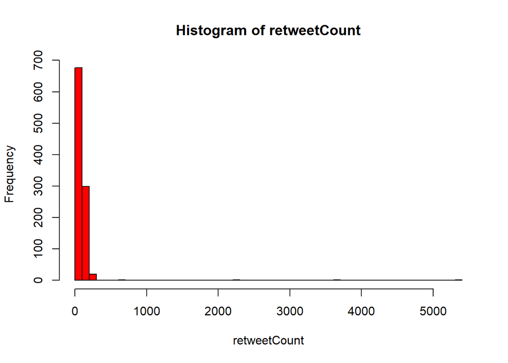

```r
retweetCount=tweets$retweet_count

hist(retweetCount,col="red",breaks = 50)
```

As the histogram of retweet count is exponenetial and skewed we take logarithm of retweet counts +1 so as to eliminate log 0 from the data

## 8.4.3

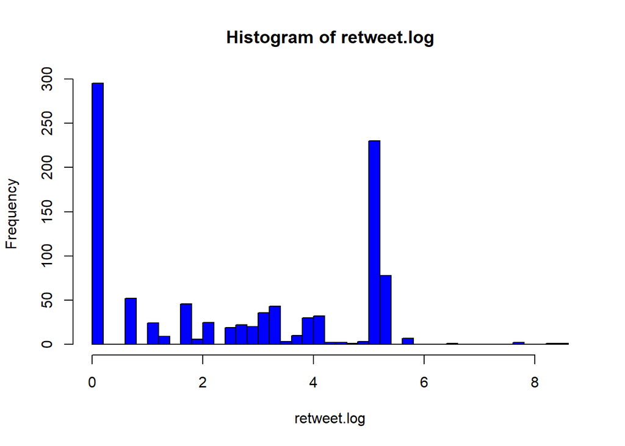

```r
retweet.log=log(retweetCount+1)

hist(retweet.log,col="blue",breaks = 50)
```

## 8.4.4

To make the graph simpler we are taking the top 20 retweeted tweets.

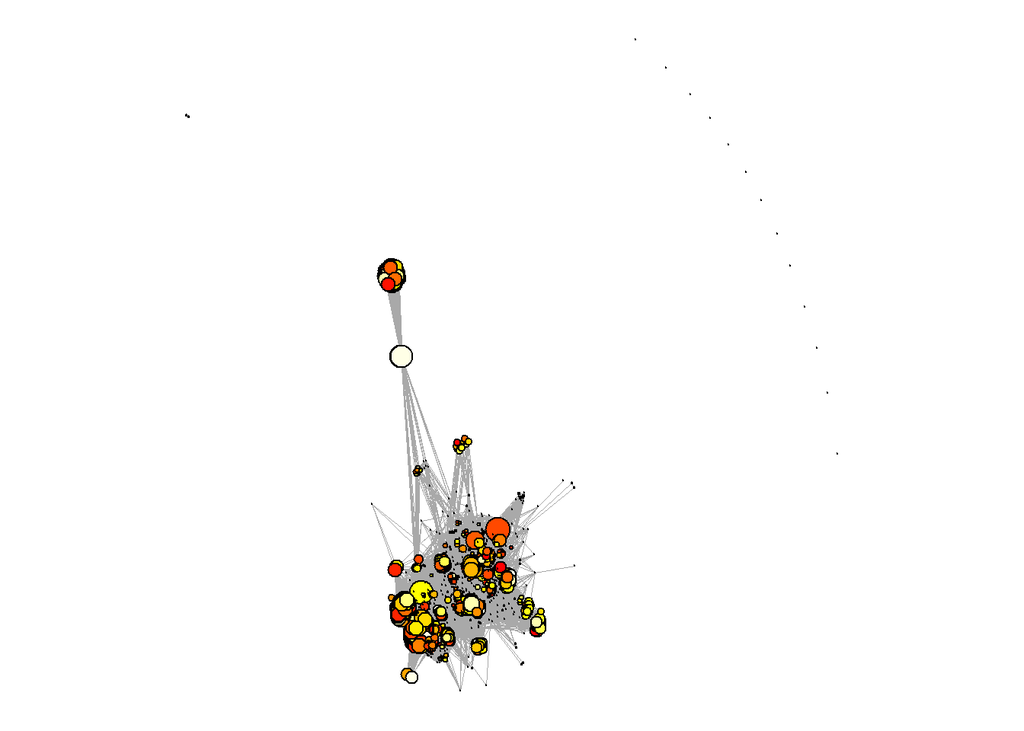

```r
graph=graph.adjacency(S,weighted = TRUE)
par(mai=c(0,0,0,0))
plot(simplify(graph),layout =layout.fruchterman.reingold, vertex.size=retweet.log*.9, vertex.label="",vertex.color=heat.colors(20),edge.width=0.5, edge.arrow.size=0)
```

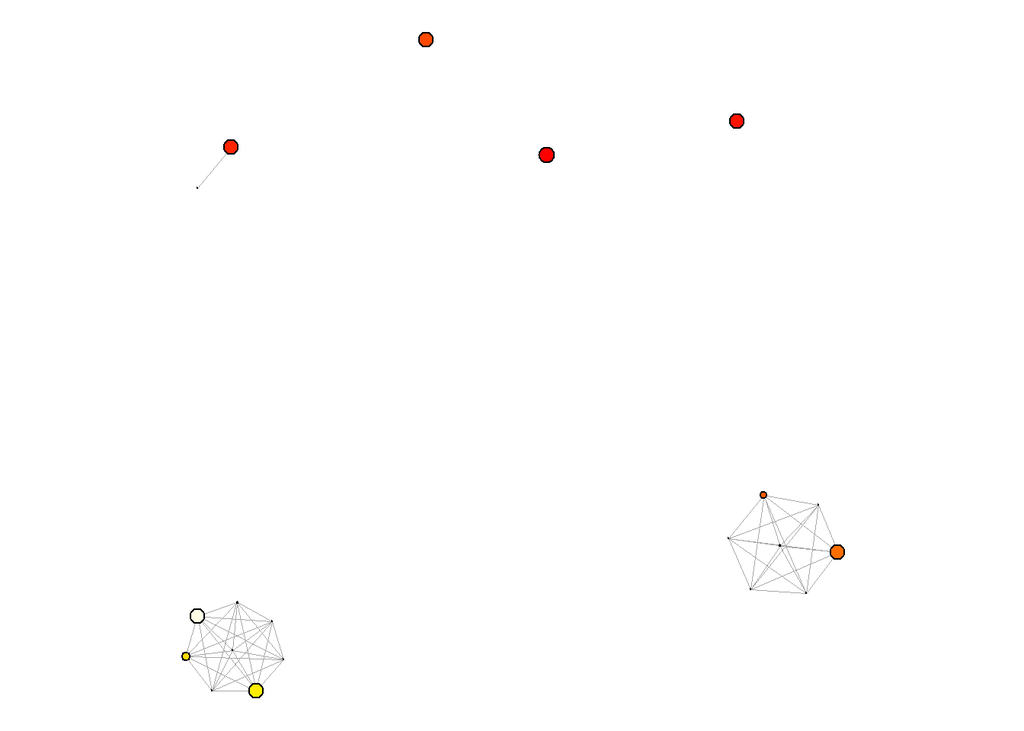

```r
id=order(retweet.log,decreasing = TRUE)[1:20]
tweets.imp=tweets[id,]
retweetCount.imp=tweets.imp$retweet_count
#retweetCount.imp
tweet.imp=tweet.matrix[id,]
s.imp=tweet.imp%*%t(tweet.imp)
set.seed(1500)
par(mai=c(0,0,0,0))
graph1=graph.adjacency(s.imp,weighted = TRUE)
plot(simplify(graph1),layout=layout.fruchterman.reingold,
     vertex.size=retweet.log*.9, edge.width=0.5,
     edge.arrow.size=0,vertex.label="",vertex.color=heat.colors(20))
```

### Results

Connected tweets mostly are the same tweets retweeted by different users.

## 8.5.1 centrality measures

### Degree centrality

```r
degCentrality=degree(graph)
topTweetsDegree=order(degCentrality,decreasing = TRUE)[1:10]
tweets$text[topTweetsDegree]
```

```
##  [1] Macaulay Culkin tweets at J.K. Rowling asking for a job - https://t.co/BYCO6Q5Rjd \n\nMacaulay Culkin wants to be part of J.K. Rowlingâ\200\230sÂ Harry Potter universe.\nAfter receiving some backlash for casting an Asian actress as a villainâ\200\231s slave in the upcoming â\200Fantastic Bea…
##  [2] Harry Potter fans really want Macaulay Culkin to get a part in Fantastic Beasts after his tweet to J.K. Rowling\nhttps://t.co/MZnaUpyggm https://t.co/CrYlJKjx26
##  [3] #1 (and only) reason I will never watch Harry Potter movies (including Fantastic Beasts) or read any of the books? J.K. Rowling.
##  [4] Elijah, I also see that Macaulay has talked to J.K. Rowling about being cast in the Fantastic Beast movie.. I'm glad to know he's back into the movies.. Feel free to write me messages on Twitter or E-Mail me at some time if you want to!!!!
##  [5] @hermioneswife @jahuraaa @piccolosturban @luciusobsessed Yikes. Tbh does J.K. Rowling even get to chose the casting 100% just from the Harry Potter series alone there werenâ\200\231t poc at all. Or the few poc described in the book werenâ\200\231t in the film or mentioned in the film
##  [6] J.K. Rowling confirms massive fan conspiracy in 'Harry Potter' universe The final trailer for the highly anticipated second installment of the "Fantastic Beasts" franchise, "The Crimes of... https://t.co/igWMjjgREQ
##  [7] I don't really have an issue with Nagini being cast as a Korean woman. No problem there.\n\nI do, however, have a problem with J.K. Rowling pulling random out of her ass about the Wizarding World.\n\nI get it: she wrote it, she can do what she wants. But it still comes across as lazy
##  [8] I've read fantastic beasts and where to find me but there isn't a book about the Crimes of Grindelwald, that I know. \n\nBut I know F.B is an extention of the wizarding world that J.K Rowling recently started. https://t.co/yKKNjU5fKj
##  [9] Macaulay Culkin sent his CV to J.K. Rowling for a part in Fantastic Beasts - now people really want him to be cast - https://t.co/sNCq6qT5AS https://t.co/3hlb8ulVbk
## [10] J K Rowling being J K Rowling. Seven books and not a single peep. In deathly hallows, Nagini is an old woman ready to jump harry. But Maledictus turn into beasts PERMANENTLY 🤦🏾‍♂️🤦🏾‍♂️🤦🏾‍♂️ https://t.co/l4Um3gIHVV
## 412 Levels: 'A racist, misogynist disaster': J.K. Rowling responds as fans slam Fantastic Beasts casting\nhttps://t.co/u1aQMhhkDV ...
```

### Closeness centrality

```r
closenessCentrality=closeness(graph)
topTweetsCloseness=order(closeness(graph),decreasing = TRUE)[1:10]
tweets$text[topTweetsCloseness]
```

```
##  [1] Me in 2016: "Oh boy, more movies set in the Harry Potter universe, written by J.K. Rowling herself! This should be fascinati--"\n\n2018: "Abusey McSparrowHatter is our bad guy and Nagini was a Korean lady the whole time."\n\nMe: https://t.co/mXO3IXzDSM
##  [2] Me in 2016: "Oh boy, more movies set in the Harry Potter universe, written by J.K. Rowling herself! This should be fascinati--"\n\n2018: "Abusey McSparrowHatter is our bad guy and Nagini was a Korean lady the whole time."\n\nMe: https://t.co/mXO3IXzDSM
##  [3] Me in 2016: "Oh boy, more movies set in the Harry Potter universe, written by J.K. Rowling herself! This should be fascinati--"\n\n2018: "Abusey McSparrowHatter is our bad guy and Nagini was a Korean lady the whole time."\n\nMe: https://t.co/mXO3IXzDSM
##  [4] Me in 2016: "Oh boy, more movies set in the Harry Potter universe, written by J.K. Rowling herself! This should be fascinati--"\n\n2018: "Abusey McSparrowHatter is our bad guy and Nagini was a Korean lady the whole time."\n\nMe: https://t.co/mXO3IXzDSM
##  [5] Me in 2016: "Oh boy, more movies set in the Harry Potter universe, written by J.K. Rowling herself! This should be fascinati--"\n\n2018: "Abusey McSparrowHatter is our bad guy and Nagini was a Korean lady the whole time."\n\nMe: https://t.co/mXO3IXzDSM
##  [6] Me in 2016: "Oh boy, more movies set in the Harry Potter universe, written by J.K. Rowling herself! This should be fascinati--"\n\n2018: "Abusey McSparrowHatter is our bad guy and Nagini was a Korean lady the whole time."\n\nMe: https://t.co/mXO3IXzDSM
##  [7] Me in 2016: "Oh boy, more movies set in the Harry Potter universe, written by J.K. Rowling herself! This should be fascinati--"\n\n2018: "Abusey McSparrowHatter is our bad guy and Nagini was a Korean lady the whole time."\n\nMe: https://t.co/mXO3IXzDSM
##  [8] @jk_rowling @J_A_Moulton Nagini is an Indian word and â\200\230Nagaâ\200\231 people are Indian mythology, which it seems J K didnâ\200\231t even think of naming as a part of Indonesian ethnic groups. \nThatâ\200\231s because she had already done Parvati so didnâ\200\231t want to double up an…
##  [9] @jk_rowling @J_A_Moulton Nagini is an Indian word and â\200\230Nagaâ\200\231 people are Indian mythology, which it seems J K didnâ\200\231t even think of naming as a part of Indonesian ethnic groups. \nThatâ\200\231s because she had already done Parvati so didnâ\200\231t want to double up an…
## [10] @jk_rowling @J_A_Moulton Nagini is an Indian word and â\200\230Nagaâ\200\231 people are Indian mythology, which it seems J K didnâ\200\231t even think of naming as a part of Indonesian ethnic groups. \nThatâ\200\231s because she had already done Parvati so didnâ\200\231t want to double up an…
## 412 Levels: 'A racist, misogynist disaster': J.K. Rowling responds as fans slam Fantastic Beasts casting\nhttps://t.co/u1aQMhhkDV ...
```

### Betweenness centrality

```r
betweennessCentrality=betweenness(graph)
topTweetsBetweenness=order(betweenness(graph),decreasing = TRUE)[1:10]
tweets$text[topTweetsBetweenness]
```

```
##  [1] J K Rowling being J K Rowling. Seven books and not a single peep. In deathly hallows, Nagini is an old woman ready to jump harry. But Maledictus turn into beasts PERMANENTLY 🤦🏾‍♂️🤦🏾‍♂️🤦🏾‍♂️ https://t.co/l4Um3gIHVV
##  [2] @hermioneswife @jahuraaa @piccolosturban @luciusobsessed Yikes. Tbh does J.K. Rowling even get to chose the casting 100% just from the Harry Potter series alone there werenâ\200\231t poc at all. Or the few poc described in the book werenâ\200\231t in the film or mentioned in the film
##  [3] So J.K. Rowling just revealed that Nagini was a human?\nLike\nShe wrote HP treating her like a pet, every character and the narrator treated her like a pet. It would make her being a slave till her death. Thatâ\200\231s gross. \n\nRowling, you just shouldâ\200\231ve added LGBTs. Far less com…
##  [4] @saltybisque @BeastsMovieUK @jk_rowling Exactly. So, why would a survivor allow and bask his casting? J.K Rowling is a survivor and if there was any truth to his case then I donâ\200\231t think she wouldâ\200\231ve been okay with it. Remember we donâ\200\231t know what truly happened but you…
##  [5] Elijah, I also see that Macaulay has talked to J.K. Rowling about being cast in the Fantastic Beast movie.. I'm glad to know he's back into the movies.. Feel free to write me messages on Twitter or E-Mail me at some time if you want to!!!!
##  [6] Major Bombshell: J.K. Rowling Has Revealed Daniel Radcliffe Is Chinese https://t.co/DKKxmNZ3Kw https://t.co/Ve03iAC1aT
##  [7] Major Bombshell: J.K. Rowling Has Revealed Daniel Radcliffe Is Chinese https://t.co/DKKxmNZ3Kw https://t.co/Ve03iAC1aT
##  [8] Don't tell J.K. Rowling. The Japanese American National Museum is the place to find fantastic beasts. Dive into the colorful world of toy designer Mark Nagata in the @jamuseum 's latest exhibit.  https://t.co/9IT90ba67z
##  [9] Macaulay Culkin Asks J.K. Rowling to Write Him into Next 'Fantastic Beasts' Movie: Macaulay Culkin wants to make another big splash in Hollywood -- and he's shamelessly, and publicly, lobbying J.K. Rowling to help him do it. The 38-year-old 'Home Alone'â\200¦ https://t.co/1GtyysXvIB https://…
## [10] @jk_rowling @J_A_Moulton Nagini is an Indian word and â\200\230Nagaâ\200\231 people are Indian mythology, which it seems J K didnâ\200\231t even think of naming as a part of Indonesian ethnic groups. \nThatâ\200\231s because she had already done Parvati so didnâ\200\231t want to double up an…
## 412 Levels: 'A racist, misogynist disaster': J.K. Rowling responds as fans slam Fantastic Beasts casting\nhttps://t.co/u1aQMhhkDV ...
```

## 8.5.2 Page rank to calculate the most influential tweets

```r
adjacency.to.probability = function(A) {
  cols = ncol(A)
  for (a in 1:cols) {
    A[, a] = normalise(A[, a])
  }
  return(A)
}
normalise=function(x){
  if(sum(x)!=0){
    x=x/sum(x)
  }else{
    x=x
  }
  return(x)
}
T = adjacency.to.probability(S)
J = matrix(rep(1/1000, 1000 * 1000), 1000, 1000)
alpha=0.8
M = alpha * T + (1 - alpha) * J
M = adjacency.to.probability(M)
#Power method to find stationary distribution
#function to calculate Euclidean distance between two vectors.
differenceEuc=function(x,y){
  return(sqrt(sum((x-y)^2)))
}
stationary.distribution = function(T) {
  # first create the initial state distribution
  n = ncol(T)
  p = rep(0, n)
  p[1] = 1

  # now take a random walk until the state distribution reaches the
  # stationary distribution.
  p.old = rep(0, n)
  while (differenceEuc(p, p.old) > 1e-06) {
    p.old = p
    p = T %*% p.old
  }
  return(p)
}

p = stationary.distribution(M)
influentialTweets=order(p,decreasing = TRUE)[1:11]
#took 11 to get 10 distinct users as one user was repeat in top10.

tweets$text[influentialTweets]
```

```
##  [1] 'Harry Potter' (1997 - 2007) was a book series by J.K. Rowling.
##  [2] Macaulay Culkin Wants J.K. Rowling to Write Him Into 'Fantastic Beasts'
##  [3] J.K. Rowling is racist. don't @ me
##  [4] We don't deserve J.K. Rowling.
##  [5] Macaulay Culkin Asks J.K. Rowling to Write Him into Next 'Fantastic Beasts' Movie https://t.co/nKU39wXgSn
##  [6] Macaulay Culkin Asks J.K. Rowling to Write Him into Next 'Fantastic Beasts' Movie https://t.co/nKU39wXgSn
##  [7] Macaulay Culkin Asks J.K. Rowling to Write Him into Next 'Fantastic Beasts' Movie https://t.co/nKU39wXgSn
##  [8] Macaulay Culkin Asks J.K. Rowling to Write Him into Next 'Fantastic Beasts' Movie https://t.co/nKU39wXgSn
##  [9] Macaulay Culkin Asks J.K. Rowling to Write Him into Next 'Fantastic Beasts' Movie https://t.co/nKU39wXgSn
## [10] Macaulay Culkin Asks J.K. Rowling to Write Him into Next 'Fantastic Beasts' Movie https://t.co/vrmGsnr6SA
## [11] Macaulay Culkin Asks J.K. Rowling to Write Him into Next 'Fantastic Beasts' Movie https://t.co/nKU39wXgSn
## 412 Levels: 'A racist, misogynist disaster': J.K. Rowling responds as fans slam Fantastic Beasts casting\nhttps://t.co/u1aQMhhkDV ...
```

## 8.5.3 Influential Users

```r
users=tweets$screen_name[influentialTweets]
unique(users)
```

```
##  [1] culturalkumite  MekoStarr       meka_activated  KaylinGie14
##  [5] SHOT97KRABDADDY BroGod4Life     KMJonAIR        RedRoman2
##  [9] FrankWHmag      Hard2bAhDiamond
## 961 Levels: __CAR0USEL__ __nocturnale _carol_clarinet ... zwolftenaugust
```

## 8.5.4 influence ratio

```r
InfluenceRatio= tweets$followers_count[influentialTweets]/
                tweets$friends_count[influentialTweets]

influence <- unique(data.frame(users,InfluenceRatio),descending=TRUE)
names(influence) <- c("User Names","Influence Ratio")
influence
```

```
##         User Names Influence Ratio
## 1   culturalkumite      61.0000000
## 2        MekoStarr       0.4434639
## 3   meka_activated       3.6000000
## 4      KaylinGie14       4.5000000
## 5  SHOT97KRABDADDY       0.8822614
## 6      BroGod4Life       0.4813763
## 7         KMJonAIR       6.0286659
## 8        RedRoman2       0.5573470
## 9       FrankWHmag       0.8508475
## 11 Hard2bAhDiamond       0.3292683
```

```r
#median followers in sample
followers.median=median(tweets$followers_count)
#median influence ratio in sample
influenceRatio.median=median(InfluenceRatio)
```

## 8.5.5 Activity measures

```r
ActivityMeasure=tweets$statuses_count[influentialTweets]
activity <- unique(data.frame(users,ActivityMeasure))
names(activity) <- c("User Names","Activity Measure")
activity
```

```
##         User Names Activity Measure
## 1   culturalkumite            70521
## 2        MekoStarr            79068
## 3   meka_activated           109267
## 4      KaylinGie14            19296
## 5  SHOT97KRABDADDY            42525
## 6      BroGod4Life            85739
## 7         KMJonAIR            86606
## 8        RedRoman2             8933
## 9       FrankWHmag            63404
## 11 Hard2bAhDiamond             2202
```

## 8.5.6 Scatter plot of users

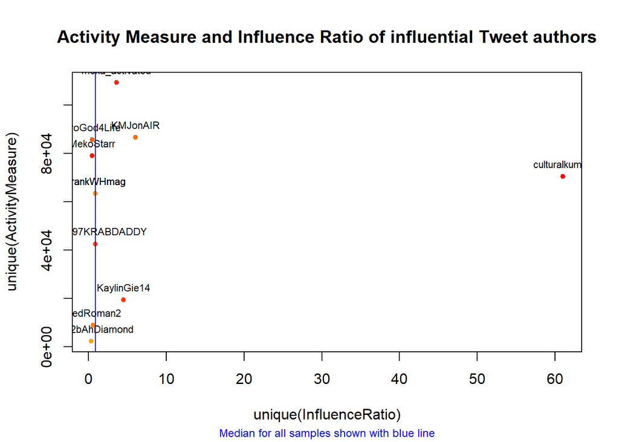

```
## integer(0)
```

## Findings

The most influential user ‘culturalkumite’ is a bot. The high influential ratio is due to it having 61 followers and following only 1 user while the median number of follows in the collected data is 461. Other users of influential tweets do not have a very high influence ratio and are most likely fans of J.K.Rowling’s work who follow more users rather than broadcasting without following, as appears the case with ‘culturalkumite’.

### Conclusion

When we consider all of our findings together we can say that J.K Rowling is intertwined with her creations from the Harry Potter novels and the subsequent film adaptations. Many of the frequent terms are actors from the film adaptions and also the film “Fantastic Beasts and Where To Find Them: The Crimes of Grindewald” which is due to be released.

We also note that because J.K. Rowling is a very well known author and has a very active twitter account there can be a huge shift of conversation topics in a short period of time and our analysis is based on only 1000 tweets from the 28th September 2018.

Shared news articles and tweets about J.K. Rowling are likely to be retweeted heavily among clusters of users, particularly if a subset of twitter users consider a subject related to her find a particular announcement to be very good or very bad.

There were some users who were accusing Rowling of racism in the charecters she created, particularly for the ‘Nagini’ role in the film Fantastic Beasts. On the other side of this is general excitement at the idea of actor Macauley Culkin expressing a desire to be cast in the series.